# GH_annotations

IP

2024-09-05

## Project goal:

### Setup

```r
#Define the subdirectories in which my annotated genomes and data exist
subdir <- list.dirs("./Muribaculaceae_genomes/Annotations", recursive=FALSE)

#Create dataframe into which the data will land
all_content <- data.frame()

#Function for reading the annotated genome data
read_dbCAN <- function(filepath,genome){
  dbCAN <- read.delim2(filepath,header=TRUE,sep="\t")
  dbCAN$Genome <- basename(genome)
  return(dbCAN)
}

#For loop reads all annotated genome data and appends to a single dataframe
for (s in subdir){
  g <- basename(s)
  s_fp <- paste(s,"/hmmer.out",sep="")
  overview_content <- read_dbCAN(s_fp,g)
  n <- nrow(overview_content) #count number of GHs
  n2 <- length(unique(overview_content$HMM.Profile))
  print(paste(g,"contains",n,"GH loci total and",n2,"unique GHs",sep=" "))
  all_content <- rbind(all_content,overview_content)}
```

```
## [1] "16COLB contains 116 GH loci total and 61 unique GHs"
## [1] "3SKV contains 117 GH loci total and 67 unique GHs"
## [1] "7BRU contains 135 GH loci total and 71 unique GHs"
## [1] "7FAA contains 104 GH loci total and 60 unique GHs"
## [1] "7GAM contains 187 GH loci total and 92 unique GHs"
## [1] "8CFAA contains 135 GH loci total and 70 unique GHs"
## [1] "8FAA contains 134 GH loci total and 69 unique GHs"
## [1] "8FAAM contains 117 GH loci total and 61 unique GHs"
## [1] "8FB contains 96 GH loci total and 50 unique GHs"
## [1] "Akkermansia contains 125 GH loci total and 57 unique GHs"
## [1] "B_theta contains 456 GH loci total and 150 unique GHs"
## [1] "DSM_28989_YL27 contains 148 GH loci total and 77 unique GHs"
## [1] "Duncaniella_6FAAM contains 173 GH loci total and 89 unique GHs"
## [1] "E_coli_K12 contains 38 GH loci total and 30 unique GHs"
## [1] "E12_NM3 contains 150 GH loci total and 78 unique GHs"
## [1] "E4_CT contains 175 GH loci total and 80 unique GHs"
## [1] "F1_NM4 contains 241 GH loci total and 111 unique GHs"
## [1] "F3_NM6 contains 150 GH loci total and 78 unique GHs"
## [1] "H11_NM74 contains 242 GH loci total and 111 unique GHs"
## [1] "H12_NM75 contains 155 GH loci total and 75 unique GHs"
## [1] "H4_NM65 contains 172 GH loci total and 80 unique GHs"
```

```r
#Move the genome column to be first :)
all_content <- all_content %>% select("Genome",everything()) %>%
  mutate(HMM.Profile = str_remove(HMM.Profile,"\\.hmm$"))
print("Genome data has been collected and merged! Proceed to next block.")
```

```
## [1] "Genome data has been collected and merged! Proceed to next block."
```

# Label substrate sources

Take plant/animal/etc labels from Carolina and add to GH info

```r
#Labels from Carolina, combined into one comprehensive list
plant=c('GH1','GH2','GH3','GH4','GH5','GH8','GH9','GH11','GH12','GH15','GH16','GH17','GH26','GH27','GH28','GH29','GH36','GH39','GH43','GH44','GH48','GH51','GH53','GH55','GH67','GH74','GH78','GH93','GH94','GH95','GH115','GH117','GH121','PL1','PL2','PL6','PL7','PL9','PL11','PL15','PL22')
animal=c('GH1','GH2','GH3','GH4','GH18','GH19','GH20','GH29','GH33','GH38','GH58','GH79','GH84','GH85','GH88','GH89','GH92','GH95','GH98','GH99','GH101','GH105','GH109','GH110','GH113','PL6', 'PL8','PL12','PL13','PL21')
pg=c('GH23','GH24','GH25','GH73','GH102','GH103','GH104','GH108')
starch=c('GH13','GH15','GH57','GH77')
sucrose=c('GH32','GH68','GH70','GH91')
fungal=c('GH5','GH8','GH16','GH18','GH19','GH20','GH55','GH64','GH71','GH81')
dextran=c('GH66','GH70','GH87')
mucin=c('GH33','CBM40','GH29-B','GH29-A','CBM32','GH29','CBM32','FIVAR','GHnc','GH95','CBM51','GH101','GH129','GH20','GH2','GH42','GH84','GH89','UNK','Fn3')
sources <- list(plant=plant,animal=animal,pg=pg,starch=starch,sucrose=sucrose,fungal=fungal,
                dextran=dextran,mucin=mucin)
sources.df <-  data.frame()
for (s in unique(unlist(sources))) {
  Sources <- names(sources)[sapply(sources, function(v) s %in% v)]
  # print(n)
  sources.df <- rbind(sources.df, data.frame(Family = s, Source = paste(Sources, collapse = ","), stringsAsFactors = FALSE))}

#Factor and sort by GH number if applicable, for cleanliness
sources.df <- sources.df %>%
  mutate(t = sub("_\\d+$", "", Family)) %>%
  mutate(n = as.numeric(sub("GH", "", t)),  t = factor(t, levels = paste0("GH", sort(unique(n))))) %>%
  select(Family,Source)
```

### Create GH-substrate databse

Create GH-substrate simple database from CAZdb download, add Carolina’s source info

```r
substrate_info <- read.delim2("fam-substrate-mapping-08012023.tsv") %>%
  select(Substrate_high_level, Family) %>% unique() %>%
  group_by(Family) %>%
  summarise(Substrates = paste(Substrate_high_level, collapse = ", "), .groups = 'drop') %>%
  filter(nzchar(Family)) %>%
  left_join(sources.df, by = join_by(Family==Family))
```

### Annotate data with function or substrate.

Note: substrate filters map one-to-one so dataset size should be unchanged.

```r
function_info <- read_xls("dbCAN-sub.substrate.mapping.xls")
all_content_function <- all_content %>%
  left_join(function_info,by= c("HMM.Profile" = "Family"),relationship="many-to-many")

#Filter for just GHs and then add substrate information
all_content_substrate <- all_content %>%
  filter(grepl("GH",HMM.Profile)) %>%
  mutate(Trimmed.Profile = sub("_\\d+$", "", HMM.Profile)) %>%
  left_join(substrate_info,by= c("Trimmed.Profile" = "Family")) %>%
  select(Genome, HMM.Profile, Trimmed.Profile, Substrates, Source,E.Value, Coverage) %>%
  mutate(
    HMM.Profile.Number = as.numeric(sub("GH", "", Trimmed.Profile)),
    Trimmed.Profile = factor(Trimmed.Profile, levels = paste0("GH", sort(unique(HMM.Profile.Number))))
  )
```

# Visualise:

Counts above a certain set value (arbitrarily 8 here) are labelled with HMM.Profile for interest.

```r
count_data <- all_content_substrate %>%
  count(Genome, Trimmed.Profile) %>%
  mutate(Label = if_else(n >= 8, as.character(Trimmed.Profile), ""))  # Create labels only for counts > 10

g <- ggplot(count_data, aes(x = Genome, y = n, fill = Trimmed.Profile)) +
  geom_bar(stat = "identity",color="black") +
  theme_minimal() +
  geom_text(aes(label = Label), position = position_stack(vjust = 0.5), color = "white",size=2) +
  labs(x = "Genome", y = "Count", fill = "HMM Profile", title = "Count of Each HMM Profile by Genome") +
  theme(axis.text.x = element_text(angle = 45, hjust = 1),
          legend.text = element_text(size = 8),
        legend.key.size = unit(8, 'pt'))
# g
```

### Heatmap of substrates

It is important to note that some GH profiles are affiliated with multiple substrates. Such pathways count towards the count for *each* substrate they include, meaning the total number of counts here will be greater than the total number of GH genes.

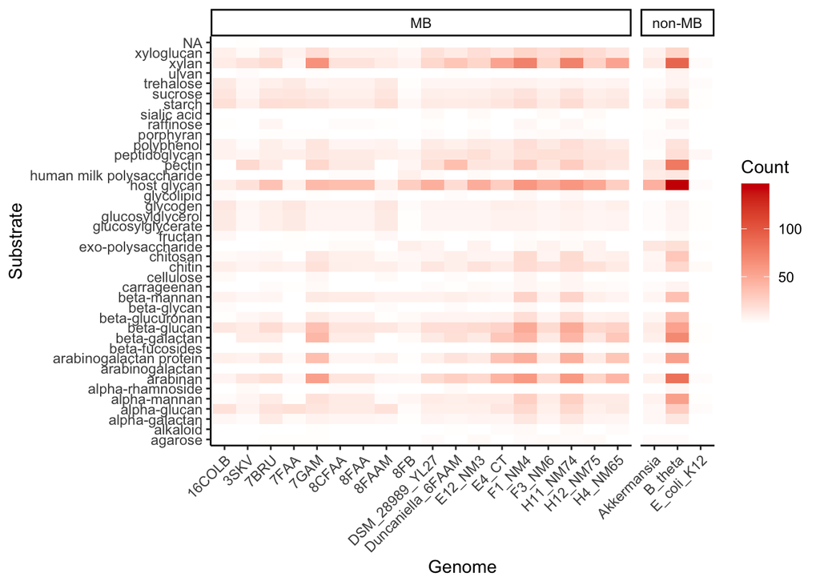

```r
non_MB <- c("B_theta", "Akkermansia", "E_coli_K12")

count_substrate <- all_content_substrate %>%
  separate_rows(Substrates, sep=", ") %>%
  count(Genome, Substrates) %>%
  mutate(Species = if_else(Genome %in% non_MB,"non-MB","MB"))

g <- ggplot(count_substrate, aes(y = Substrates, x = Genome, fill = n)) +
  geom_tile() +
  scale_fill_gradient(low = "white", high = "red3") +
  labs(y = "Substrate", x = "Genome", fill = "Count") +
  theme_classic() +
  facet_grid(~Species, scales = "free_x", space = "free_x") +
  theme(axis.text.x = element_text(angle = 45, hjust = 1))
g
```

```r
# ggsave("heatmap_GH_substrate.pdf",scale=2)
```

### Heatmap of sources

It is important to note that some GH profiles are affiliated with multiple sources Such pathways count towards the count for *each* source they include, meaning the total number of counts here will be greater than the total number of GH genes.

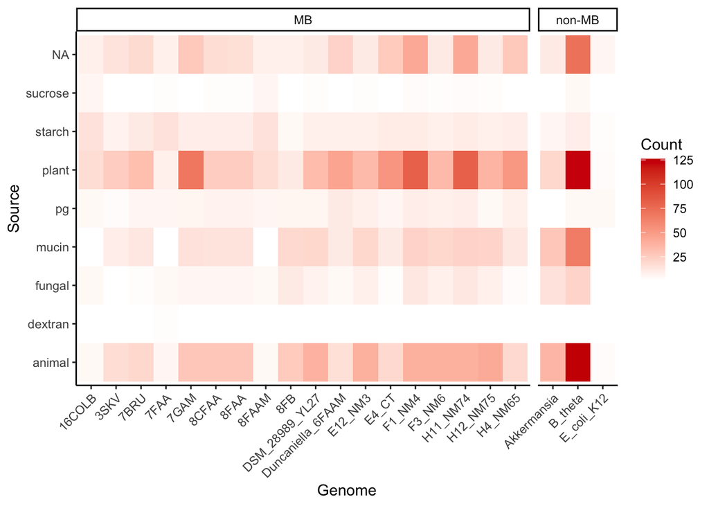

```r
non_MB <- c("B_theta", "Akkermansia", "E_coli_K12")

count_source <- all_content_substrate %>%
  separate_rows(Source, sep=",") %>%
  count(Genome, Source) %>%
  mutate(Species = if_else(Genome %in% non_MB,"non-MB","MB"))

g <- ggplot(count_source, aes(y = Source, x = Genome, fill = n)) +
  geom_tile() +
  scale_fill_gradient(low = "white", high = "red3") +
  labs(y = "Source", x = "Genome", fill = "Count") +
  theme_classic() +
  facet_grid(~Species, scales = "free_x", space = "free_x") +
  theme(axis.text.x = element_text(angle = 45, hjust = 1))

g
```

```r
# ggsave("heatmap_GH_sources.pdf",scale=2)
```